# Write up on developing a ML algorithm to predict type of exercised sports

This is a write up for Coursera’s course Practical Machine Learning. It describes how a machine learning algorithm was developed to predict the manner in which people did certain sports exercises by using sensor data collected from devices such as Jawbone Up, Nike FuelBand and Fitbit. More information about the source data is available at http://groupware.les.inf.puc-rio.br/har (see the section on the Weight Lifting Exercise Dataset).

Building the model included the following phases:

- General settings
- Reading data in and splitting it into train and test datasets
- Transforming the training data
- Training a machine learning algorithm by using training data
- Estimating accuracy of the algorithm by using testing data
- Testing the solution with provided test cases

## General settings

Prerequisites: pml-training.csv and pml-testing.csv source data files are expected to be found from the working directory. These are available for download at Coursera site.

Lets load required libraries and set seed to ensure reproducibility.

```r
library(caret)
set.seed(12345)
```

## Reading data in and splitting it into train and test datasets

Data used for developing an algorithm was provided in pml-training.csv. The file contains several columns with plenty of missing values. We treat ‘NA’, ‘#DIV/0!’ and empty values as missing ones.

After reading in the data, We split it in two parts randomly:

- 80% of the data is used for training an algorithm (training) and
- 20% of the data is used for evaluating its accuracy (testing)

```r
data <- read.csv("pml-training.csv",
                 header=TRUE,
                 na.strings=c("NA", "#DIV/0!", ""))
inTrain <- createDataPartition(y=data$classe, p=0.8, list=FALSE)
training <- data[inTrain,]
testing <- data[-inTrain,]
```

Source data contains 19622 rows and 160 columns in total.

Though having little understanding on both weight lifting and used sensors, the dataset appears to have a lot of sensor readings, with each row related to certain sports exercise style described by a variable classe, which is to be predicted. Defining which of the columns contain relevant data for predicting classe was not obvious.

## Transforming the training data

Training data contains 15699 rows and 160 columns. However, a brief study indicated that several columns contained mostly NA values. In addition, columns 1-7 contained user information, time stamps, windows etc which were not relevant, as time series based model was not planned to be used. As a result, the following transformations were made:

- remove columns 1-7
- remove columns containing NA values
- remove column with names starting as total_, as these compose data contained by other columns

```r
training <- training[-c(1:7)]
training <- training[, apply(training, 2, function(x) !any(is.na(x)))]
training <- training[, -grep("^total_", colnames(training))]
```

After the transformations, training data contains 15699 rows and 49 columns. All columns are numeric or integer except classe, which is factor and presents the manner in which the subject did the exercise - it is to be predicted.

nearZeroVar diagnose is used for detecting possible variables that have one unique value (i.e. are zero variance predictors) and predictors that are have both of the following characteristics: they have very few unique values relative to the number of samples and the ratio of the frequency of the most common value to the frequency of the second most common value is large. It did not result in removing variables.

```r
nearZeroVar(training)
```

```
## integer(0)
```

Correlated variables were identified in order to remove duplicate information. The correlation level of interest was set to 0.9.

```r
cors <- abs(cor(training[,-grep("classe", colnames(training))]))
diag(cors) <- 0
cors[cors < 0.9] <- NA
cors <- cors[, apply(cors, 2, function(x) !all(is.na(x)))]
cors <- cors[apply(cors, 1, function(x) !all(is.na(x))), ]
cors
```

```
##                  roll_belt pitch_belt accel_belt_x accel_belt_y
## roll_belt               NA         NA           NA    0.9248137
## pitch_belt              NA         NA    0.9660057           NA
## accel_belt_x            NA  0.9660057           NA           NA
## accel_belt_y     0.9248137         NA           NA           NA
## accel_belt_z     0.9919748         NA           NA    0.9334302
## gyros_arm_x             NA         NA           NA           NA
## gyros_arm_y             NA         NA           NA           NA
## gyros_dumbbell_x        NA         NA           NA           NA
## gyros_dumbbell_z        NA         NA           NA           NA
## gyros_forearm_z         NA         NA           NA           NA
##                  accel_belt_z gyros_arm_x gyros_arm_y gyros_dumbbell_x
## roll_belt           0.9919748          NA          NA               NA
## pitch_belt                 NA          NA          NA               NA
## accel_belt_x               NA          NA          NA               NA
## accel_belt_y        0.9334302          NA          NA               NA
## accel_belt_z               NA          NA          NA               NA
## gyros_arm_x                NA          NA   0.9181279               NA
## gyros_arm_y                NA   0.9181279          NA               NA
## gyros_dumbbell_x           NA          NA          NA               NA
## gyros_dumbbell_z           NA          NA          NA        0.9833764
## gyros_forearm_z            NA          NA          NA        0.9305413
##                  gyros_dumbbell_z gyros_forearm_z
## roll_belt                      NA              NA
## pitch_belt                     NA              NA
## accel_belt_x                   NA              NA
## accel_belt_y                   NA              NA
## accel_belt_z                   NA              NA
## gyros_arm_x                    NA              NA
## gyros_arm_y                    NA              NA
## gyros_dumbbell_x        0.9833764       0.9305413
## gyros_dumbbell_z               NA       0.9457249
## gyros_forearm_z         0.9457249              NA
```

The following variables were found correlating and removed:

- roll_belt correlates with accel_belt_y and accel_belt_z
- pitch_belt correlates with accel_belt_x
- gyros_dumbbell_x correlates with gyros_dumbbell_z and gyros_forearm_z
- gyros_arm_x correlates with gyros_arm_y

```r
training <- training[,!(names(training) %in% c("accel_belt_y",
                                               "accel_belt_z",
                                               "accel_belt_x",
                                               "gyros_dumbbell_z",
                                               "gyros_forearm_z",
                                               "gyros_arm_y"))]
```

## Training a machine learning algorithm by using training data

As a next step, we train a machine learning algorithm by using the training data. Random forest seems like a good choice thanks to its accuracy.

Lets use repeated k-fold cross validation, in which the process of splitting the data into k-folds is repeated a number of times. The final model accuracy is taken as the mean from the number of repeats. For the sake of processing time, we use 3-fold cross validation with 3 repeats.

```r
train_control <- trainControl(method="repeatedcv", number=3, repeats=3)
model <- train(classe ~ .,
               data=training,
               trControl=train_control,
               method="rf",
               prox = TRUE)
```

This model is based on several variables, as we can also notice from varImpPlot, which plots variable importance as measured by a random forest model.

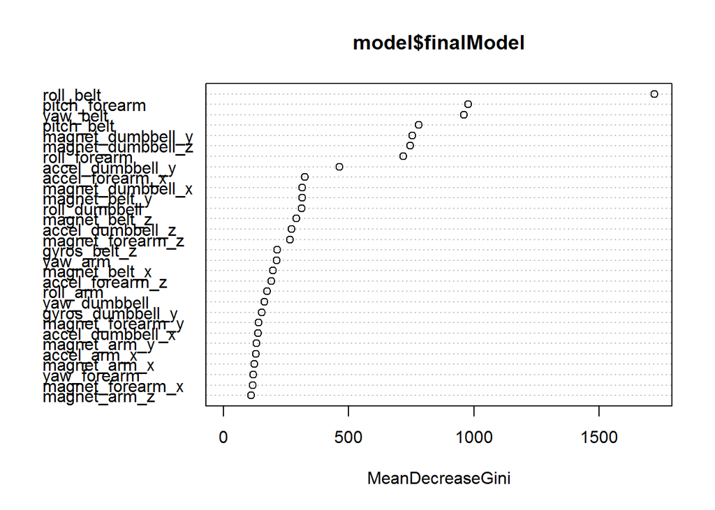

```r
varImpPlot(model$finalModel)
```

To avoid overfitting, we reduce amount of predictor variables. We pick the 15 most important ones from the model developed above.

```r
varImp <- varImp(model$finalModel)
varImp <- rownames(varImp)[order(varImp$Overall, decreasing=TRUE)][1:15]
training <- training[,(names(training) %in% c(varImp, "classe"))]
```

Now, we build the final model by using only these predictors

```r
train_control2 <- trainControl(method="repeatedcv", number=3, repeats=3)
model2 <- train(classe ~ .,
                data=training,
                trControl=train_control2,
                method="rf",
                prox = TRUE)
```

The resulting model is summarized below. OOB estimate of error rate is 1,05%.

```r
print(model2)
```

```
## Random Forest
##
## 15699 samples
##    15 predictor
##     5 classes: 'A', 'B', 'C', 'D', 'E'
##
## No pre-processing
## Resampling: Cross-Validated (3 fold, repeated 3 times)
##
## Summary of sample sizes: 10466, 10465, 10467, 10466, 10467, 10465, ...
##
## Resampling results across tuning parameters:
##
##   mtry  Accuracy   Kappa      Accuracy SD  Kappa SD
##    2    0.9843939  0.9802574  0.001365243  0.001726813
##    8    0.9844789  0.9803674  0.001864226  0.002358458
##   15    0.9787036  0.9730639  0.003149725  0.003982743
##
## Accuracy was used to select the optimal model using  the largest value.
## The final value used for the model was mtry = 8.
```

```r
print(model2$finalModel)
```

```
##
## Call:
##  randomForest(x = x, y = y, mtry = param$mtry, proximity = TRUE)
##                Type of random forest: classification
##                      Number of trees: 500
## No. of variables tried at each split: 8
##
##         OOB estimate of  error rate: 1.05%
## Confusion matrix:
##      A    B    C    D    E class.error
## A 4449    8    4    2    1 0.003360215
## B   22 2991   23    2    0 0.015470704
## C    0   21 2698   19    0 0.014609204
## D    0    3   24 2541    5 0.012436844
## E    0    5   13   13 2855 0.010741511
```

## Estimating accuracy of the algorithm by using testing data

We estimate accuracy of the model by using testing data, which was not used when training the model and use it for estimating the out of sample error. The real out of sample error is likely to be slightly higher.

```r
predict <- predict(model2, newdata=testing)
confusionMatrix(predict, testing$classe)
```

```
## Confusion Matrix and Statistics
##
##           Reference
## Prediction    A    B    C    D    E
##          A 1114    5    1    0    0
##          B    1  743    7    0    2
##          C    1   10  674    5    1
##          D    0    1    2  637    3
##          E    0    0    0    1  715
##
## Overall Statistics
##
##                Accuracy : 0.9898
##                  95% CI : (0.9861, 0.9927)
##     No Information Rate : 0.2845
##     P-Value [Acc > NIR] : < 2.2e-16
##
##                   Kappa : 0.9871
##  Mcnemar's Test P-Value : NA
##
## Statistics by Class:
##
##                      Class: A Class: B Class: C Class: D Class: E
## Sensitivity            0.9982   0.9789   0.9854   0.9907   0.9917
## Specificity            0.9979   0.9968   0.9948   0.9982   0.9997
## Pos Pred Value         0.9946   0.9867   0.9754   0.9907   0.9986
## Neg Pred Value         0.9993   0.9950   0.9969   0.9982   0.9981
## Prevalence             0.2845   0.1935   0.1744   0.1639   0.1838
## Detection Rate         0.2840   0.1894   0.1718   0.1624   0.1823
## Detection Prevalence   0.2855   0.1919   0.1761   0.1639   0.1825
## Balanced Accuracy      0.9980   0.9879   0.9901   0.9944   0.9957
```

As a conclusion, the model seem to perform rather accurately, having accuracy 0.9898, Kappa 0.9871 and sensitivity and specificity for all classes classes higher than 0.9789.

We have tried to minimize risk of overfitting by reducing amount of variables used in the model.

The effect of reducing more variables and using other algortihms could be studied further.

## Testing the solution with provided test cases

20 test cases were provided for testing the developed algorithm. The following code was used for generating the results submitted for grading. 20/20 score was achieved.

```r
pml_write_files = function(x){
  n = length(x)
  for(i in 1:n){
    filename = paste0("problem_id_",i,".txt")
    write.table(x[i],file=filename,quote=FALSE,row.names=FALSE,col.names=FALSE)
  }
}

testdata <- read.csv("pml-testing.csv",
                     header=TRUE,
                     na.strings=c("NA", "#DIV/0!", ""))
answers <- predict(model2, newdata=testdata)
pml_write_files(answers)
```